# Various spawner recruit relationships for depensatory dynamics

# Background

Here we explore various parameterizations of stock recruit relationships (SRRs) that show evidence of depensation. There are many parameterizaitons for both Ricker and Beverton-Holt type spawner recruit relationships (SRRs) but we will focus on some basics. Most of these derivations arise from a need for how to treat the depensatory parameter, with some having a goal of making the depensatory parameter biologically relevant.

## Ricker based SRRs

There are 3 types we will explore here.  
- original [Ricker](https://cdnsciencepub.com/doi/10.1139/f54-039) from 1954  
- depensatory Ricker ([Quinn & Deriso, 1999](https://books.google.ca/books/about/Quantitative_Fish_Dynamics.html?id=5FVBj8jnh6sC&redir_esc=y), p. 99)  
- Saila-Lorda (as described in [Perälä & Kuparinen, 2017](http://dx.doi.org/10.1098/rspb.2017.1284))

To understand these models we’ll describe their structure, simulate data based on the Saila-Lorda then fit each SRR to the simulated data.

#### Quinn & Deriso’s 4 parameter depensatory Ricker SRR

$$R = \alpha Se^{\beta S - \delta
S^{\gamma }}$$
The authors say that this model is depensatory when $S^{\gamma -1} < \beta / (\gamma \delta)$, which isn’t very intuitive, which brings us to the next model.

#### Salia-Lorda SRR

$$R_{t} = k(\frac{S_{t}}{S_{k}})^{c}e^{c
(1-S_{t}/S_{k})}$$
where $R_{t}$ and $S_{t}$ are vectors of recruits and spawners at time *t*, *k* is the maximum number of recruits produced when $S_{t} = S_{k}$ and $S_{k}$ is is the spawning stock at which the number of recruits is *k*. *c* is the depensatory parameter; *c* = 1 produces the classic Ricker, *c* > 1 shows depensatory dynamics, and *c* < 1 shows hypercompensaiton.

## Simulation

We’ll simulate some data from a Salia-Lorda to play with. FEEL FREE to toggle the parameters (i.e. S, Sk, k, c, sigma), they will cascade through the robust code

```r
S <- runif(100, 10, 1000) #vector of random spawners
Sk <- 600
k <- 200
c <- 3
sigma <- rnorm(length(S), 0, 50) #random white noise error
```

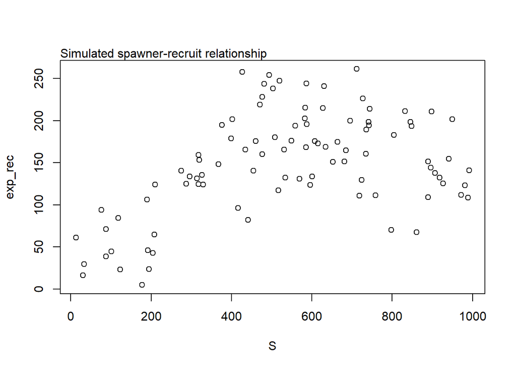

## Fit simulated data

Can fit a Ricker here the “old fashioned” way by making it linear.

```
##                Estimate   Std. Error   t value     Pr(>|t|)
## (Intercept) -0.43748203 0.1208903788 -3.618832 4.811714e-04
## spawners    -0.00145724 0.0002014439 -7.233971 1.304485e-10
```

now we can use optim to fit a non linear Quinn & Deriso model

| alpha | 0.6457 |
| --- | --- |
| beta | -0.0015 |
| delta | 1 |
| gamma | 1 |
| sd | 2.3026 |

Now we’ll refit the Salia-Lorda and plot the results

| Sk | 573.68 |
| --- | --- |
| k | 186.68 |
| c | 1.99 |
| sd | 3.72 |

Now we’ll generate model predictions from the parameter fits

Then plot it

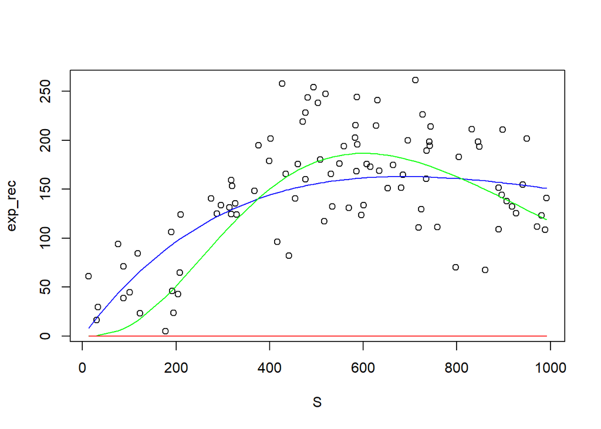

**NOTE** that the Quinn & Deriso SR model (red) is currently BROKEN!

We could add variations of the Beverton-Holt, which are generally easier to fit. These could include:  
- classic Beverton-Holt without depensation  
- Myers’ Beverton-Holt from the ’95 [paper](https://www.science.org/doi/10.1126/science.269.5227.1106) in *Science*  
- The Beverton-Holt fit in the Perala et al [paper](https://royalsocietypublishing.org/doi/10.1098/rsbl.2021.0439)  
- [Lierman & Hilborn’s](https://cdnsciencepub.com/doi/abs/10.1139/f97-105) stepwise way of fitting a depensatory Beverton-Holt with meaningful parameters